# Assignment 09: Data Scraping

Xuening Tang

## OVERVIEW

This exercise accompanies the lessons in Environmental Data Analytics on data scraping.

## Directions

1. Rename this file `<FirstLast>_A09_DataScraping.Rmd` (replacing `<FirstLast>` with your first and last name).
2. Change “Student Name” on line 3 (above) with your name.
3. Work through the steps, **creating code and output** that fulfill each instruction.
4. Be sure to **answer the questions** in this assignment document.
5. When you have completed the assignment, **Knit** the text and code into a single PDF file.

## Set up

1. Set up your session:
- Check your working directory
- Load the packages `tidyverse`, `rvest`, and any others you end up using.
- Set your ggplot theme

```r
#1
getwd()
```

```
## [1] "/Users/xueningtang/Desktop/R lab/EDA-Fall2022/Assignments"
```

```r
library(tidyverse)
library(rvest)
library(lubridate)

my.theme <- theme_classic(base_size = 12) +
  theme(axis.text = element_text(color = "black"),
        legend.position = "top")
theme_set(my.theme)
```

2. We will be scraping data from the NC DEQs Local Water Supply Planning website, specifically the Durham’s 2021 Municipal Local Water Supply Plan (LWSP):
- Navigate to https://www.ncwater.org/WUDC/app/LWSP/search.php
- Scroll down and select the LWSP link next to Durham Municipality.
- Note the web address: https://www.ncwater.org/WUDC/app/LWSP/report.php?pwsid=03-32-010&year=2021

Indicate this website as the as the URL to be scraped. (In other words, read the contents into an `rvest` webpage object.)

```r
#2
webpage.1 <- read_html('https://www.ncwater.org/WUDC/app/LWSP/report.php?pwsid=03-32-010&year=2021')
webpage.1
```

```
## {html_document}
## <html xmlns="http://www.w3.org/1999/xhtml" lang="en" xml:lang="en">
## [1] <head>\n<title>DWR :: Local Water Supply Planning</title>\n<meta http-equ ...
## [2] <body id="plan">\r\n<!--<div id="division-header">\r\n<a name="top" href= ...
```

3. The data we want to collect are listed below:
- From the “1. System Information” section:
- Water system name
- PSWID
- Ownership
- From the “3. Water Supply Sources” section:
- Maximum Daily Use (MGD) - for each month

In the code chunk below scrape these values, assigning them to four separate variables.

> HINT: The first value should be “Durham”, the second “03-32-010”, the third “Municipality”, and the last should be a vector of 12 numeric values (represented as strings), with the first value being “27.6400”.

```r
#3
water.system.name <- webpage.1 %>%
  html_nodes("div+ table tr:nth-child(1) td:nth-child(2)") %>%
  html_text()

pswid <- webpage.1 %>%
  html_nodes("td tr:nth-child(1) td:nth-child(5)") %>%
  html_text()

ownership <- webpage.1 %>%
  html_nodes("div+ table tr:nth-child(2) td:nth-child(4)") %>%
  html_text()

max.withdrawals.mgd <- webpage.1 %>%
  html_nodes("th~ td+ td") %>%
  html_text()
```

4. Convert your scraped data into a dataframe. This dataframe should have a column for each of the 4 variables scraped and a row for the month corresponding to the withdrawal data. Also add a Date column that includes your month and year in data format. (Feel free to add a Year column too, if you wish.)

> TIP: Use `rep()` to repeat a value when creating a dataframe.

> NOTE: It’s likely you won’t be able to scrape the monthly widthrawal data in chronological order. You can overcome this by creating a month column manually assigning values in the order the data are scraped: “Jan”, “May”, “Sept”, “Feb”, etc…
5. Create a line plot of the maximum daily withdrawals across the months for 2021

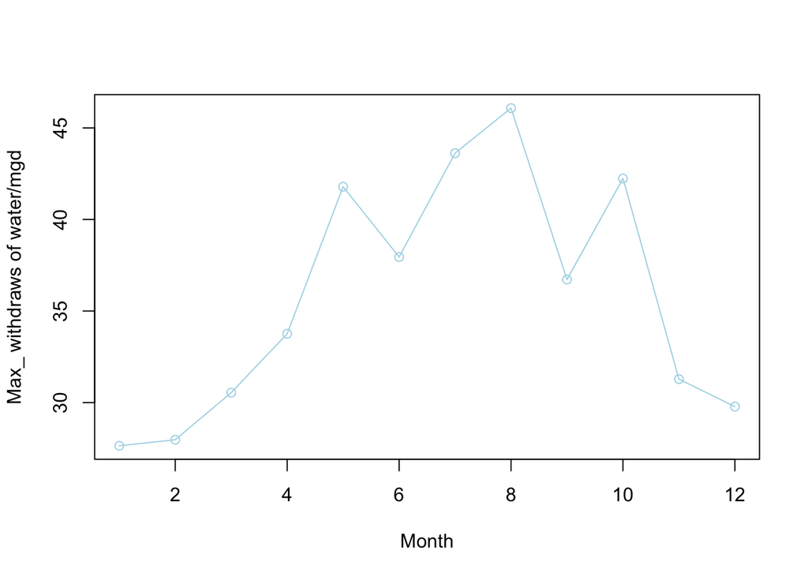

```r
#4
Max_withdraws_mgd <- data.frame(max.withdrawals.mgd)
Max_final <- Max_withdraws_mgd[c(1,4,7,10,2,5,8,11,3,6,9,12),]

df_water <- data.frame("max.withdrawals.mgd" = Max_final,
                       "Month" = rep(1:12),
                       "Year" = rep(2021,12))%>%
  mutate(Water_System_Name = !!water.system.name,
         PSWID = !!pswid,
         Ownership = !!ownership,
         Date = my(paste(Month,"-",Year)))



#5

plot(df_water$max.withdrawals.mgd,type = "o", col = "light blue", xlab = "Month", ylab = "Max_ withdraws of water/mgd")
```

6. Note that the PWSID and the year appear in the web address for the page we scraped. Construct a function using your code above that can scrape data for any PWSID and year for which the NC DEQ has data. **Be sure to modify the code to reflect the year and site (pwsid) scraped**.

```r
#6.
base_url <- 'https://www.ncwater.org/WUDC/app/LWSP/report.php'
my_PWSID <- 'pwsid=03-43-015'
my_Year <- 'year=2017'
my_scrape_url <- paste0(base_url, '?', my_PWSID, '&', my_Year)
print(my_scrape_url)
```

```
## [1] "https://www.ncwater.org/WUDC/app/LWSP/report.php?pwsid=03-43-015&year=2017"
```

```r
my_website <- read_html(my_scrape_url)
my_system_name_tag <- 'div+ table tr:nth-child(1) td:nth-child(2)'
my_pwsid_tag <- 'td tr:nth-child(1) td:nth-child(5)'
my_ownership_tag <- 'div+ table tr:nth-child(2) td:nth-child(4)'
my_max_withdraw_tag <- 'th~ td+ td'

my_system_name <- my_website %>% html_nodes(my_system_name_tag) %>% html_text()
my_pwsid_name <- my_website %>% html_nodes(my_pwsid_tag) %>%html_text()
my_ownership <- my_website %>% html_nodes(my_ownership_tag) %>% html_text()
my_max_withdrawals <- my_website %>% html_nodes(my_max_withdraw_tag)%>%html_text()


my_scrape <- function(my_PWSID,my_Year){
  my_website <- read_html(paste0('https://www.ncwater.org/WUDC/app/LWSP/report.php'
                                , '?pwsid=', my_PWSID, '&year=', my_Year))

  my_system_name_tag <- 'div+ table tr:nth-child(1) td:nth-child(2)'
  my_pwsid_tag <- 'td tr:nth-child(1) td:nth-child(5)'
  my_ownership_tag <- 'div+ table tr:nth-child(2) td:nth-child(4)'
  my_max_withdraw_tag <- 'th~ td+ td'

  my_system_name <- my_website %>% html_nodes(my_system_name_tag) %>% html_text()
  my_pwsid_name <- my_website %>% html_nodes(my_pwsid_tag) %>%html_text()
  my_ownership <- my_website %>% html_nodes(my_ownership_tag) %>% html_text()
  my_max_withdrawals <- my_website %>% html_nodes(my_max_withdraw_tag)%>%html_text()

  df_water <- data.frame("max.withdrawals.mgd" = as.numeric(my_max_withdrawals),
                       "Year" = rep(my_Year,12))%>%
  mutate(Water_System_Name = !!my_system_name,
         PWSID = !!my_pwsid_name,
         Ownership = !!my_ownership)

return(df_water)
}
```

7. Use the function above to extract and plot max daily withdrawals for Durham (PWSID=‘03-32-010’) for each month in 2015

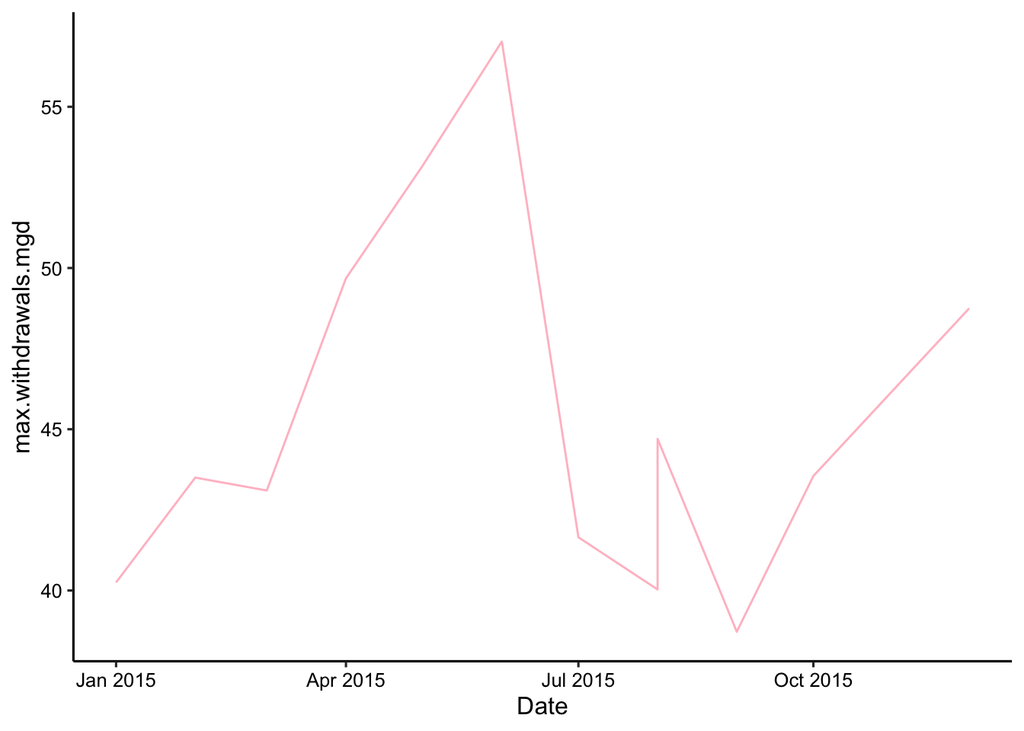

```r
#7
durh_df <- my_scrape('03-32-010','2015')
view(durh_df)

df_durh <- durh_df %>%
  mutate(Month = c(1,5,8,2,6,9,3,7,10,4,8,12),
         Date = my(paste(Month,"-",Year)))
durh_final <- df_durh[c(1,4,7,10,2,5,8,11,3,6,9,12),]

ggplot(df_durh,aes(x=Date,y=max.withdrawals.mgd)) +
  geom_line(color="pink")
```

8. Use the function above to extract data for Asheville (PWSID = 01-11-010) in 2015. Combine this data with the Durham data collected above and create a plot that compares Asheville’s to Durham’s water withdrawals.

```r
#8
df_ashe <- my_scrape('01-11-010','2015')
view(df_ashe)
ashe_df <- df_ashe %>%
  mutate(Month = c(1,5,8,2,6,9,3,7,10,4,8,12),
         Date = my(paste(Month,"-",Year)))
ashe_final <- ashe_df[c(1,4,7,10,2,5,8,11,3,6,9,12),]

df_combine <- full_join(ashe_final,durh_final)
```

[output not shown]

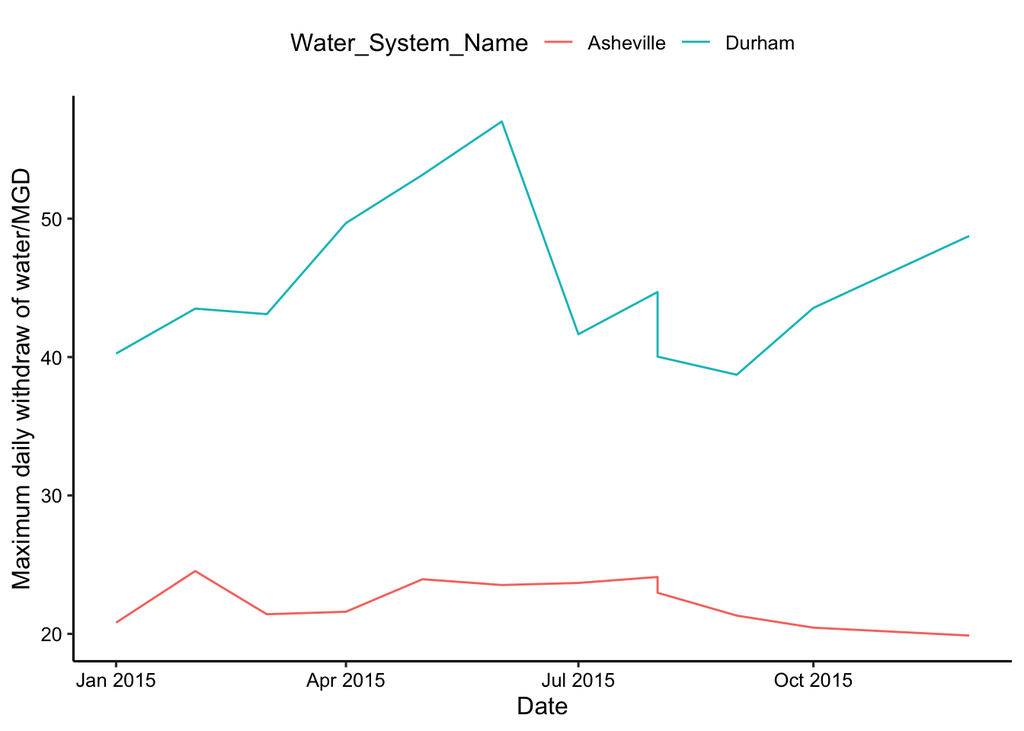

```r
water.plot<-
  ggplot(df_combine,aes(x=Date,y=max.withdrawals.mgd, color=Water_System_Name)) +
  geom_line()+
  ylab("Maximum daily withdraw of water/MGD")+
  my.theme
print(water.plot)
```

9. Use the code & function you created above to plot Asheville’s max daily withdrawal by months for the years 2010 thru 2019.Add a smoothed line to the plot.

> TIP: See Section 3.2 in the “09_Data_Scraping.Rmd” where we apply “map2()” to iteratively run a function over two inputs. Pipe the output of the map2() function to `bindrows()` to combine the dataframes into a single one.

```r
#9
my_years = rep(2010:2019)
the_pwsid = '01-11-010'
```

[output not shown]

[output not shown]